# Introducción a los receptores GNSS de bajo costo

Sistemas GNSS (2). Fuentes de error en sistemas GNSS, posicionamiento preciso, correcciones diferenciales, GNSS-RTK, resolución de errores

José Ramón Martínez Batlle (Tw: @geografiard; GitHub: @geofis)

Universidad Autónoma de Santo Domingo 4-8 de septiembre, 2023 Santo Domingo, República Dominicana https://geofis.github.io/rtk-para-todos/curso-sep23-t1.html

# Fuentes de error

- Errores ionosféricos y troposféricos: Variaciones en la ionosfera y troposfera que afectan la velocidad de propagación de la señal GNSS, resultando en errores de posición.
- Errores de órbita: Imprecisión en el conocimiento de la posición exacta del satélite en su órbita, lo que lleva a errores en el cálculo de la distancia entre el satélite y el receptor.
- Errores de reloj del satélite: Pequeñas desviaciones en el tiempo emitido por el reloj a bordo del satélite, afectando la precisión en la medición de la distancia entre el satélite y el receptor.

# Posicionamiento preciso

## Técnicas Diferenciales

- **RTK (Real-Time Kinematic)**: Utiliza una estación base y un receptor móvil para ofrecer correcciones en tiempo real y alcanzar una alta precisión de posicionamiento en centímetros.
- **DGNSS (Differential GNSS)**: Utiliza una estación base para calcular las diferencias de corrección que se aplican al receptor móvil, mejorando la precisión en relación con el GNSS estándar.
- **VRS (Virtual Reference Station)**: Genera una estación de referencia virtual cerca del receptor móvil para ofrecer correcciones diferenciales más precisas.
- **NRTK (Network RTK)**: Usa una red de estaciones base para generar modelos de corrección más precisos que se transmiten al receptor en tiempo real.
- **SBAS (Satellite-Based Augmentation System)**: Utiliza satélites geoestacionarios para transmitir correcciones y confiabilidad de la información de otros satélites GNSS a nivel continental.
- **GBAS (Ground-Based Augmentation System)**: Similar al SBAS pero centrado en una área más pequeña, como un aeropuerto, usando estaciones terrestres locales para transmitir correcciones.

## Técnicas No Diferenciales

- **PPP (Precise Point Positioning)**: Utiliza datos de múltiples satélites y modelos precisos para lograr una alta precisión sin necesidad de una estación base cercana.
- **PPP-RTK (Precise Point Positioning Real-Time Kinematic)**: Híbrido entre PPP y RTK, ofrece alta precisión en tiempo real sin una estación base cercana.
- **Multi-GNSS y Multi-frecuencia**: Utiliza señales de múltiples constelaciones y frecuencias para mejorar la precisión y robustez.
- **INS/GNSS Fusion**: Combina datos de sistemas de navegación inercial y GNSS para mantener la precisión en entornos con señal GNSS débil o nula.
- **L-Band Corrections**: Servicios comerciales que ofrecen correcciones globales de alta precisión a través de satélites de comunicación en la banda L.

## ¿Qué es RTK? Vistazo general

- Siglas de *real-time kinematic*, es una técnica de **navegación satelital global**, que utiliza la **fase de la onda portadora** (a diferencia de la técnica convencional, basada en códigos pseudoaleatorios de baja frecuencia) enviada por satélites de posicionamiento, tales como GPS, GLONASS, Galileo y BeiDou, para calcular, con **precisión centimétrica**, la distancia entre una estación base de coordenadas conocidas y una estación exploradora o *rover*.
- Veamos el vídeo de 2021, [“Introducción a GNSS-RTK…”](https://www.youtube.com/watch?v=UpI1wDkYSgY&list=PLDcT2n8UzsCRwLvmM2AfdNjK39RzRHTmZ&index=1&t=1911s), específicamente el segmento línea de tiempo entre 31:51 y 1:06:16.

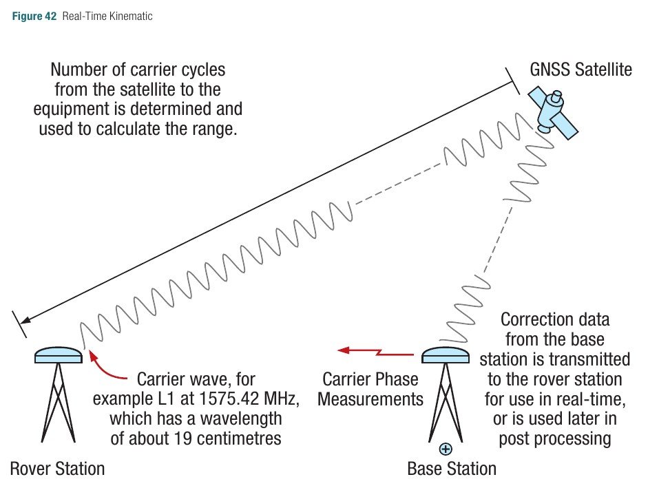

Según NovAtel (2015)

# ¿Por qué más frecuencias ayudan mejoran el posicionamiento preciso?

- Porque de un mismo sector de la atmósfera se tienen observaciones en dos frecuencias distintas, las cuales podemos relacionar por correlación para resolver la ambigüedad del entero.
- Precisión Mejorada: La utilización de dos frecuencias permite corregir errores ionosféricos, aumentando la precisión en el posicionamiento.
- Convergencia Rápida: Al usar dos frecuencias, el tiempo necesario para obtener una solución RTK fiable se reduce.
- Robustez: Mayor resistencia a interferencias y a pérdidas temporales de señal, haciendo que la solución sea más estable.

# REFERENCIAS

NovAtel. (2015). *An introduction to GNSS: GPS, GLONASS, galileo and other global navigation satellite systems*. NovAtel.